# Risk Factor Analysis

## Outcome Variable

**Outcome Variable:** ever_stunted

## Predictor Variables

**Intervention Variable:** tr

**Adjustment Set:**

unadjusted

## Stratifying Variables

The analysis was stratified on these variable(s):

- agecat
- studyid
- country
- intXmbmi

## Data Summary

| agecat | studyid | country | intXmbmi | ever_stunted | n_cell | n |
| --- | --- | --- | --- | --- | --- | --- |
| 0-6 months | ki1000110-WASH-Bangladesh | BANGLADESH | Normal weight_0-6 months | 0 | 140 | 158 |
| 0-6 months | ki1000110-WASH-Bangladesh | BANGLADESH | Normal weight_0-6 months | 1 | 18 | 158 |
| 0-6 months | ki1000110-WASH-Bangladesh | BANGLADESH | Underweight_0-6 months | 0 | 56 | 61 |
| 0-6 months | ki1000110-WASH-Bangladesh | BANGLADESH | Underweight_0-6 months | 1 | 5 | 61 |
| 0-6 months | ki1000110-WASH-Bangladesh | BANGLADESH | Overweight or Obese_0-6 months | 0 | 13 | 13 |
| 0-6 months | ki1000110-WASH-Bangladesh | BANGLADESH | Overweight or Obese_0-6 months | 1 | 0 | 13 |
| 0-6 months | ki1000125-AgaKhanUniv | PAKISTAN | Overweight or Obese_0-6 months | 0 | 76 | 97 |
| 0-6 months | ki1000125-AgaKhanUniv | PAKISTAN | Overweight or Obese_0-6 months | 1 | 21 | 97 |
| 0-6 months | ki1000304b-SAS-CompFeed | INDIA | Normal weight_0-6 months | 0 | 365 | 496 |
| 0-6 months | ki1000304b-SAS-CompFeed | INDIA | Normal weight_0-6 months | 1 | 131 | 496 |
| 0-6 months | ki1000304b-SAS-CompFeed | INDIA | Underweight_0-6 months | 0 | 115 | 181 |
| 0-6 months | ki1000304b-SAS-CompFeed | INDIA | Underweight_0-6 months | 1 | 66 | 181 |
| 0-6 months | ki1000304b-SAS-CompFeed | INDIA | Overweight or Obese_0-6 months | 0 | 31 | 36 |
| 0-6 months | ki1000304b-SAS-CompFeed | INDIA | Overweight or Obese_0-6 months | 1 | 5 | 36 |
| 0-6 months | ki1017093b-PROVIDE | BANGLADESH | Normal weight_0-6 months | 0 | 353 | 405 |
| 0-6 months | ki1017093b-PROVIDE | BANGLADESH | Normal weight_0-6 months | 1 | 52 | 405 |
| 0-6 months | ki1017093b-PROVIDE | BANGLADESH | Underweight_0-6 months | 0 | 94 | 118 |
| 0-6 months | ki1017093b-PROVIDE | BANGLADESH | Underweight_0-6 months | 1 | 24 | 118 |
| 0-6 months | ki1017093b-PROVIDE | BANGLADESH | Overweight or Obese_0-6 months | 0 | 104 | 116 |
| 0-6 months | ki1017093b-PROVIDE | BANGLADESH | Overweight or Obese_0-6 months | 1 | 12 | 116 |
| 0-6 months | ki1066203-TanzaniaChild2 | TANZANIA, UNITED REPUBLIC OF | Normal weight_0-6 months | 0 | 1057 | 1149 |
| 0-6 months | ki1066203-TanzaniaChild2 | TANZANIA, UNITED REPUBLIC OF | Normal weight_0-6 months | 1 | 92 | 1149 |
| 0-6 months | ki1066203-TanzaniaChild2 | TANZANIA, UNITED REPUBLIC OF | Underweight_0-6 months | 0 | 31 | 35 |
| 0-6 months | ki1066203-TanzaniaChild2 | TANZANIA, UNITED REPUBLIC OF | Underweight_0-6 months | 1 | 4 | 35 |
| 0-6 months | ki1066203-TanzaniaChild2 | TANZANIA, UNITED REPUBLIC OF | Overweight or Obese_0-6 months | 0 | 945 | 1003 |
| 0-6 months | ki1066203-TanzaniaChild2 | TANZANIA, UNITED REPUBLIC OF | Overweight or Obese_0-6 months | 1 | 58 | 1003 |
| 0-6 months | ki1112895-Burkina Faso Zn | BURKINA FASO | Normal weight_0-6 months | 0 | 28 | 31 |
| 0-6 months | ki1112895-Burkina Faso Zn | BURKINA FASO | Normal weight_0-6 months | 1 | 3 | 31 |
| 0-6 months | ki1112895-Burkina Faso Zn | BURKINA FASO | Underweight_0-6 months | 0 | 3 | 5 |
| 0-6 months | ki1112895-Burkina Faso Zn | BURKINA FASO | Underweight_0-6 months | 1 | 2 | 5 |

[output cut: 98 more lines]

The following strata were considered:

- agecat: 0-6 months, studyid: ki1000110-WASH-Bangladesh, country: BANGLADESH, intXmbmi: Normal weight_0-6 months
- agecat: 0-6 months, studyid: ki1000110-WASH-Bangladesh, country: BANGLADESH, intXmbmi: Overweight or Obese_0-6 months
- agecat: 0-6 months, studyid: ki1000110-WASH-Bangladesh, country: BANGLADESH, intXmbmi: Underweight_0-6 months
- agecat: 0-6 months, studyid: ki1000125-AgaKhanUniv, country: PAKISTAN, intXmbmi: Overweight or Obese_0-6 months
- agecat: 0-6 months, studyid: ki1000304b-SAS-CompFeed, country: INDIA, intXmbmi: Normal weight_0-6 months
- agecat: 0-6 months, studyid: ki1000304b-SAS-CompFeed, country: INDIA, intXmbmi: Overweight or Obese_0-6 months
- agecat: 0-6 months, studyid: ki1000304b-SAS-CompFeed, country: INDIA, intXmbmi: Underweight_0-6 months
- agecat: 0-6 months, studyid: ki1017093b-PROVIDE, country: BANGLADESH, intXmbmi: Normal weight_0-6 months
- agecat: 0-6 months, studyid: ki1017093b-PROVIDE, country: BANGLADESH, intXmbmi: Overweight or Obese_0-6 months
- agecat: 0-6 months, studyid: ki1017093b-PROVIDE, country: BANGLADESH, intXmbmi: Underweight_0-6 months
- agecat: 0-6 months, studyid: ki1066203-TanzaniaChild2, country: TANZANIA, UNITED REPUBLIC OF, intXmbmi: Normal weight_0-6 months
- agecat: 0-6 months, studyid: ki1066203-TanzaniaChild2, country: TANZANIA, UNITED REPUBLIC OF, intXmbmi: Overweight or Obese_0-6 months
- agecat: 0-6 months, studyid: ki1066203-TanzaniaChild2, country: TANZANIA, UNITED REPUBLIC OF, intXmbmi: Underweight_0-6 months
- agecat: 0-6 months, studyid: ki1112895-Burkina Faso Zn, country: BURKINA FASO, intXmbmi: Normal weight_0-6 months
- agecat: 0-6 months, studyid: ki1112895-Burkina Faso Zn, country: BURKINA FASO, intXmbmi: Overweight or Obese_0-6 months
- agecat: 0-6 months, studyid: ki1112895-Burkina Faso Zn, country: BURKINA FASO, intXmbmi: Underweight_0-6 months
- agecat: 0-6 months, studyid: ki1119695-PROBIT, country: BELARUS, intXmbmi: Normal weight_0-6 months
- agecat: 0-6 months, studyid: ki1119695-PROBIT, country: BELARUS, intXmbmi: Overweight or Obese_0-6 months
- agecat: 0-6 months, studyid: ki1119695-PROBIT, country: BELARUS, intXmbmi: Underweight_0-6 months
- agecat: 0-6 months, studyid: ki1126311-ZVITAMBO, country: ZIMBABWE, intXmbmi: Normal weight_0-6 months
- agecat: 0-6 months, studyid: ki1126311-ZVITAMBO, country: ZIMBABWE, intXmbmi: Overweight or Obese_0-6 months
- agecat: 0-6 months, studyid: ki1126311-ZVITAMBO, country: ZIMBABWE, intXmbmi: Underweight_0-6 months
- agecat: 0-6 months, studyid: ki1148112-iLiNS-DOSE, country: MALAWI, intXmbmi: Normal weight_0-6 months
- agecat: 0-6 months, studyid: ki1148112-iLiNS-DOSE, country: MALAWI, intXmbmi: Overweight or Obese_0-6 months
- agecat: 0-6 months, studyid: ki1148112-iLiNS-DOSE, country: MALAWI, intXmbmi: Underweight_0-6 months
- agecat: 0-6 months, studyid: ki1148112-LCNI-5, country: MALAWI, intXmbmi: Normal weight_0-6 months
- agecat: 0-6 months, studyid: ki1148112-LCNI-5, country: MALAWI, intXmbmi: Overweight or Obese_0-6 months
- agecat: 0-6 months, studyid: ki1148112-LCNI-5, country: MALAWI, intXmbmi: Underweight_0-6 months
- agecat: 6-24 months, studyid: iLiNS_DYADM_LNS, country: MALAWI, intXmbmi: Normal weight_6-24 months
- agecat: 6-24 months, studyid: iLiNS-Zinc_ZvLNS, country: BURKINA FASO, intXmbmi: Normal weight_6-24 months
- agecat: 6-24 months, studyid: iLiNS-Zinc_ZvLNS, country: BURKINA FASO, intXmbmi: Overweight or Obese_6-24 months
- agecat: 6-24 months, studyid: iLiNS-Zinc_ZvLNS, country: BURKINA FASO, intXmbmi: Underweight_6-24 months
- agecat: 6-24 months, studyid: ki1000110-WASH-Bangladesh, country: BANGLADESH, intXmbmi: Normal weight_6-24 months
- agecat: 6-24 months, studyid: ki1000110-WASH-Bangladesh, country: BANGLADESH, intXmbmi: Overweight or Obese_6-24 months
- agecat: 6-24 months, studyid: ki1000110-WASH-Bangladesh, country: BANGLADESH, intXmbmi: Underweight_6-24 months
- agecat: 6-24 months, studyid: ki1000125-AgaKhanUniv, country: PAKISTAN, intXmbmi: Overweight or Obese_6-24 months
- agecat: 6-24 months, studyid: ki1000304b-SAS-CompFeed, country: INDIA, intXmbmi: Normal weight_6-24 months
- agecat: 6-24 months, studyid: ki1000304b-SAS-CompFeed, country: INDIA, intXmbmi: Overweight or Obese_6-24 months
- agecat: 6-24 months, studyid: ki1000304b-SAS-CompFeed, country: INDIA, intXmbmi: Underweight_6-24 months
- agecat: 6-24 months, studyid: ki1017093b-PROVIDE, country: BANGLADESH, intXmbmi: Normal weight_6-24 months
- agecat: 6-24 months, studyid: ki1017093b-PROVIDE, country: BANGLADESH, intXmbmi: Overweight or Obese_6-24 months
- agecat: 6-24 months, studyid: ki1017093b-PROVIDE, country: BANGLADESH, intXmbmi: Underweight_6-24 months
- agecat: 6-24 months, studyid: ki1066203-TanzaniaChild2, country: TANZANIA, UNITED REPUBLIC OF, intXmbmi: Normal weight_6-24 months
- agecat: 6-24 months, studyid: ki1066203-TanzaniaChild2, country: TANZANIA, UNITED REPUBLIC OF, intXmbmi: Overweight or Obese_6-24 months
- agecat: 6-24 months, studyid: ki1066203-TanzaniaChild2, country: TANZANIA, UNITED REPUBLIC OF, intXmbmi: Underweight_6-24 months
- agecat: 6-24 months, studyid: ki1112895-Burkina Faso Zn, country: BURKINA FASO, intXmbmi: Normal weight_6-24 months
- agecat: 6-24 months, studyid: ki1112895-Burkina Faso Zn, country: BURKINA FASO, intXmbmi: Overweight or Obese_6-24 months
- agecat: 6-24 months, studyid: ki1112895-Burkina Faso Zn, country: BURKINA FASO, intXmbmi: Underweight_6-24 months
- agecat: 6-24 months, studyid: ki1112895-iLiNS-Zinc, country: BURKINA FASO, intXmbmi: Normal weight_6-24 months
- agecat: 6-24 months, studyid: ki1112895-iLiNS-Zinc, country: BURKINA FASO, intXmbmi: Overweight or Obese_6-24 months
- agecat: 6-24 months, studyid: ki1112895-iLiNS-Zinc, country: BURKINA FASO, intXmbmi: Underweight_6-24 months
- agecat: 6-24 months, studyid: ki1119695-PROBIT, country: BELARUS, intXmbmi: Normal weight_6-24 months
- agecat: 6-24 months, studyid: ki1119695-PROBIT, country: BELARUS, intXmbmi: Overweight or Obese_6-24 months
- agecat: 6-24 months, studyid: ki1119695-PROBIT, country: BELARUS, intXmbmi: Underweight_6-24 months
- agecat: 6-24 months, studyid: ki1126311-ZVITAMBO, country: ZIMBABWE, intXmbmi: Normal weight_6-24 months
- agecat: 6-24 months, studyid: ki1126311-ZVITAMBO, country: ZIMBABWE, intXmbmi: Overweight or Obese_6-24 months
- agecat: 6-24 months, studyid: ki1126311-ZVITAMBO, country: ZIMBABWE, intXmbmi: Underweight_6-24 months
- agecat: 6-24 months, studyid: ki1148112-iLiNS-DOSE, country: MALAWI, intXmbmi: Normal weight_6-24 months
- agecat: 6-24 months, studyid: ki1148112-iLiNS-DOSE, country: MALAWI, intXmbmi: Overweight or Obese_6-24 months
- agecat: 6-24 months, studyid: ki1148112-iLiNS-DOSE, country: MALAWI, intXmbmi: Underweight_6-24 months
- agecat: 6-24 months, studyid: ki1148112-iLiNS-DYAD-M, country: MALAWI, intXmbmi: Normal weight_6-24 months
- agecat: 6-24 months, studyid: ki1148112-LCNI-5, country: MALAWI, intXmbmi: Normal weight_6-24 months
- agecat: 6-24 months, studyid: ki1148112-LCNI-5, country: MALAWI, intXmbmi: Overweight or Obese_6-24 months
- agecat: 6-24 months, studyid: ki1148112-LCNI-5, country: MALAWI, intXmbmi: Underweight_6-24 months

### Dropped Strata

Some strata were dropped due to rare outcomes:

- agecat: 0-6 months, studyid: ki1000110-WASH-Bangladesh, country: BANGLADESH, intXmbmi: Overweight or Obese_0-6 months
- agecat: 0-6 months, studyid: ki1066203-TanzaniaChild2, country: TANZANIA, UNITED REPUBLIC OF, intXmbmi: Underweight_0-6 months
- agecat: 0-6 months, studyid: ki1112895-Burkina Faso Zn, country: BURKINA FASO, intXmbmi: Normal weight_0-6 months
- agecat: 0-6 months, studyid: ki1112895-Burkina Faso Zn, country: BURKINA FASO, intXmbmi: Underweight_0-6 months
- agecat: 0-6 months, studyid: ki1112895-Burkina Faso Zn, country: BURKINA FASO, intXmbmi: Overweight or Obese_0-6 months
- agecat: 0-6 months, studyid: ki1148112-LCNI-5, country: MALAWI, intXmbmi: Overweight or Obese_0-6 months
- agecat: 6-24 months, studyid: iLiNS_DYADM_LNS, country: MALAWI, intXmbmi: Normal weight_6-24 months
- agecat: 6-24 months, studyid: ki1017093b-PROVIDE, country: BANGLADESH, intXmbmi: Overweight or Obese_6-24 months
- agecat: 6-24 months, studyid: ki1148112-iLiNS-DYAD-M, country: MALAWI, intXmbmi: Normal weight_6-24 months

## Methods Detail

We’re interested in the causal parameters $E[Y_a]$ for all values of $a \in \mathcal{A}$. These parameters represent the mean outcome if, possibly contrary to fact, we intervened to set all units to have $A=a$. Under the randomization and positivity assumptions, these are identified by the statistical parameters $\psi_a=E_W[E_{Y|A,W}(Y|A=a,W)]$. In addition, we’re interested in the mean of $Y$, $E[Y]$ under no intervention (the observed mean). We will estimate these parameters by using SuperLearner to fit the relevant likelihood factors – $E_{Y|A,W}(Y|A=a,W)$ and $p(A=a|W)$, and then updating our likelihood fit using a joint TMLE.

For unadjusted analyses ($W=\{\}$), initial likelihoods were estimated using Lrnr_glm to estimate the simple $E(Y|A)$ and Lrnr_mean to estimate $p(A)$. For adjusted analyses, a small library containing Lrnr_glmnet, Lrnr_xgboost, and Lrnr_mean was used.

Having estimated these parameters, we will then use the delta method to estimate relative risks and attributable risks relative to a prespecified baseline level of $A$.

[output not shown]

# Results Detail

## Results Plots

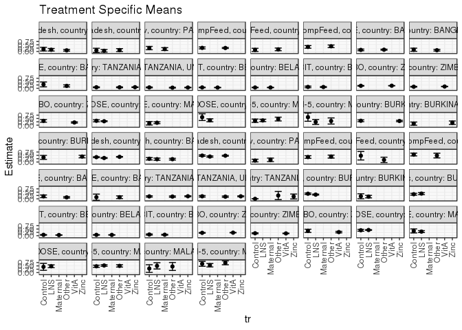

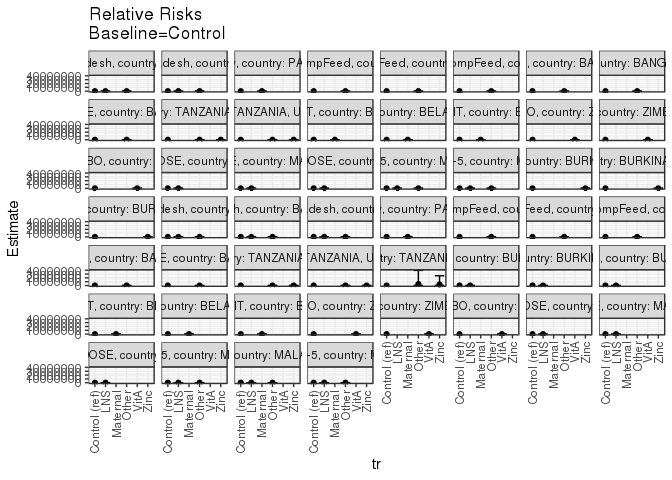

[figure not shown]

[figure not shown]

## Results Table

### Parameter: TSM

| agecat | studyid | country | intXmbmi | intervention_level | baseline_level | estimate | ci_lower | ci_upper |
| --- | --- | --- | --- | --- | --- | --- | --- | --- |
| 0-6 months | ki1000110-WASH-Bangladesh | BANGLADESH | Normal weight_0-6 months | Control | NA | 0.1724138 | 0.0344960 | 0.3103316 |
| 0-6 months | ki1000110-WASH-Bangladesh | BANGLADESH | Normal weight_0-6 months | LNS | NA | 0.1276596 | 0.0319517 | 0.2233674 |
| 0-6 months | ki1000110-WASH-Bangladesh | BANGLADESH | Normal weight_0-6 months | Other | NA | 0.0853659 | 0.0246942 | 0.1460375 |
| 0-6 months | ki1000110-WASH-Bangladesh | BANGLADESH | Underweight_0-6 months | Control | NA | 0.0833333 | -0.0743413 | 0.2410080 |
| 0-6 months | ki1000110-WASH-Bangladesh | BANGLADESH | Underweight_0-6 months | LNS | NA | 0.0500000 | -0.0463095 | 0.1463095 |
| 0-6 months | ki1000110-WASH-Bangladesh | BANGLADESH | Underweight_0-6 months | Other | NA | 0.1034483 | -0.0083121 | 0.2152086 |
| 0-6 months | ki1000125-AgaKhanUniv | PAKISTAN | Overweight or Obese_0-6 months | Control | NA | 0.2553191 | 0.1300119 | 0.3806264 |
| 0-6 months | ki1000125-AgaKhanUniv | PAKISTAN | Overweight or Obese_0-6 months | Maternal | NA | 0.1800000 | 0.0729574 | 0.2870426 |
| 0-6 months | ki1000304b-SAS-CompFeed | INDIA | Normal weight_0-6 months | Control | NA | 0.2681818 | 0.1983923 | 0.3379713 |
| 0-6 months | ki1000304b-SAS-CompFeed | INDIA | Normal weight_0-6 months | Other | NA | 0.2608696 | 0.2240848 | 0.2976543 |
| 0-6 months | ki1000304b-SAS-CompFeed | INDIA | Underweight_0-6 months | Control | NA | 0.3409091 | 0.2413392 | 0.4404790 |
| 0-6 months | ki1000304b-SAS-CompFeed | INDIA | Underweight_0-6 months | Other | NA | 0.3870968 | 0.2871792 | 0.4870144 |
| 0-6 months | ki1000304b-SAS-CompFeed | INDIA | Overweight or Obese_0-6 months | Control | NA | 0.1176471 | -0.0028997 | 0.2381938 |
| 0-6 months | ki1000304b-SAS-CompFeed | INDIA | Overweight or Obese_0-6 months | Other | NA | 0.1578947 | 0.0560628 | 0.2597267 |
| 0-6 months | ki1017093b-PROVIDE | BANGLADESH | Normal weight_0-6 months | Control | NA | 0.1171171 | 0.0572229 | 0.1770114 |
| 0-6 months | ki1017093b-PROVIDE | BANGLADESH | Normal weight_0-6 months | Other | NA | 0.1326531 | 0.0938321 | 0.1714740 |
| 0-6 months | ki1017093b-PROVIDE | BANGLADESH | Underweight_0-6 months | Control | NA | 0.2916667 | 0.1090448 | 0.4742885 |
| 0-6 months | ki1017093b-PROVIDE | BANGLADESH | Underweight_0-6 months | Other | NA | 0.1808511 | 0.1027109 | 0.2589912 |
| 0-6 months | ki1017093b-PROVIDE | BANGLADESH | Overweight or Obese_0-6 months | Control | NA | 0.1290323 | 0.0105107 | 0.2475539 |
| 0-6 months | ki1017093b-PROVIDE | BANGLADESH | Overweight or Obese_0-6 months | Other | NA | 0.0941176 | 0.0317743 | 0.1564610 |
| 0-6 months | ki1066203-TanzaniaChild2 | TANZANIA, UNITED REPUBLIC OF | Normal weight_0-6 months | Control | NA | 0.0776699 | 0.0478142 | 0.1075256 |
| 0-6 months | ki1066203-TanzaniaChild2 | TANZANIA, UNITED REPUBLIC OF | Normal weight_0-6 months | Other | NA | 0.0758123 | 0.0446272 | 0.1069974 |
| 0-6 months | ki1066203-TanzaniaChild2 | TANZANIA, UNITED REPUBLIC OF | Normal weight_0-6 months | Zinc | NA | 0.0834813 | 0.0606228 | 0.1063399 |
| 0-6 months | ki1066203-TanzaniaChild2 | TANZANIA, UNITED REPUBLIC OF | Overweight or Obese_0-6 months | Control | NA | 0.0669456 | 0.0352441 | 0.0986471 |
| 0-6 months | ki1066203-TanzaniaChild2 | TANZANIA, UNITED REPUBLIC OF | Overweight or Obese_0-6 months | Other | NA | 0.0480000 | 0.0214885 | 0.0745115 |
| 0-6 months | ki1066203-TanzaniaChild2 | TANZANIA, UNITED REPUBLIC OF | Overweight or Obese_0-6 months | Zinc | NA | 0.0583658 | 0.0380888 | 0.0786427 |
| 0-6 months | ki1119695-PROBIT | BELARUS | Normal weight_0-6 months | Control | NA | 0.0650640 | 0.0443706 | 0.0857574 |
| 0-6 months | ki1119695-PROBIT | BELARUS | Normal weight_0-6 months | Maternal | NA | 0.0565153 | 0.0411916 | 0.0718390 |
| 0-6 months | ki1119695-PROBIT | BELARUS | Underweight_0-6 months | Control | NA | 0.1040000 | 0.0461916 | 0.1618084 |
| 0-6 months | ki1119695-PROBIT | BELARUS | Underweight_0-6 months | Maternal | NA | 0.0968992 | 0.0597881 | 0.1340104 |

[output cut: 89 more lines]

### Parameter: E(Y)

| agecat | studyid | country | intXmbmi | intervention_level | baseline_level | estimate | ci_lower | ci_upper |
| --- | --- | --- | --- | --- | --- | --- | --- | --- |
| 0-6 months | ki1000110-WASH-Bangladesh | BANGLADESH | Normal weight_0-6 months | NA | NA | 0.1139241 | 0.0642258 | 0.1636223 |
| 0-6 months | ki1000110-WASH-Bangladesh | BANGLADESH | Underweight_0-6 months | NA | NA | 0.0819672 | 0.0125573 | 0.1513771 |
| 0-6 months | ki1000125-AgaKhanUniv | PAKISTAN | Overweight or Obese_0-6 months | NA | NA | 0.2164948 | 0.1341081 | 0.2988816 |
| 0-6 months | ki1000304b-SAS-CompFeed | INDIA | Normal weight_0-6 months | NA | NA | 0.2641129 | 0.2269106 | 0.3013152 |
| 0-6 months | ki1000304b-SAS-CompFeed | INDIA | Underweight_0-6 months | NA | NA | 0.3646409 | 0.2909908 | 0.4382910 |
| 0-6 months | ki1000304b-SAS-CompFeed | INDIA | Overweight or Obese_0-6 months | NA | NA | 0.1388889 | 0.0580087 | 0.2197690 |
| 0-6 months | ki1017093b-PROVIDE | BANGLADESH | Normal weight_0-6 months | NA | NA | 0.1283951 | 0.0957745 | 0.1610156 |
| 0-6 months | ki1017093b-PROVIDE | BANGLADESH | Underweight_0-6 months | NA | NA | 0.2033898 | 0.1304537 | 0.2763260 |
| 0-6 months | ki1017093b-PROVIDE | BANGLADESH | Overweight or Obese_0-6 months | NA | NA | 0.1034483 | 0.0477876 | 0.1591090 |
| 0-6 months | ki1066203-TanzaniaChild2 | TANZANIA, UNITED REPUBLIC OF | Normal weight_0-6 months | NA | NA | 0.0800696 | 0.0643700 | 0.0957692 |
| 0-6 months | ki1066203-TanzaniaChild2 | TANZANIA, UNITED REPUBLIC OF | Overweight or Obese_0-6 months | NA | NA | 0.0578265 | 0.0433740 | 0.0722790 |
| 0-6 months | ki1119695-PROBIT | BELARUS | Normal weight_0-6 months | NA | NA | 0.0606676 | 0.0475470 | 0.0737882 |
| 0-6 months | ki1119695-PROBIT | BELARUS | Underweight_0-6 months | NA | NA | 0.1003937 | 0.0665070 | 0.1342804 |
| 0-6 months | ki1119695-PROBIT | BELARUS | Overweight or Obese_0-6 months | NA | NA | 0.0601719 | 0.0482917 | 0.0720522 |
| 0-6 months | ki1126311-ZVITAMBO | ZIMBABWE | Normal weight_0-6 months | NA | NA | 0.1931905 | 0.1824876 | 0.2038934 |
| 0-6 months | ki1126311-ZVITAMBO | ZIMBABWE | Underweight_0-6 months | NA | NA | 0.2279793 | 0.1860729 | 0.2698856 |
| 0-6 months | ki1126311-ZVITAMBO | ZIMBABWE | Overweight or Obese_0-6 months | NA | NA | 0.1307420 | 0.1158930 | 0.1455911 |
| 0-6 months | ki1148112-iLiNS-DOSE | MALAWI | Normal weight_0-6 months | NA | NA | 0.2987421 | 0.2696826 | 0.3278017 |
| 0-6 months | ki1148112-iLiNS-DOSE | MALAWI | Underweight_0-6 months | NA | NA | 0.4069767 | 0.3025386 | 0.5114149 |
| 0-6 months | ki1148112-iLiNS-DOSE | MALAWI | Overweight or Obese_0-6 months | NA | NA | 0.1744966 | 0.1133503 | 0.2356429 |
| 0-6 months | ki1148112-LCNI-5 | MALAWI | Normal weight_0-6 months | NA | NA | 0.3720930 | 0.3073319 | 0.4368542 |
| 0-6 months | ki1148112-LCNI-5 | MALAWI | Underweight_0-6 months | NA | NA | 0.3404255 | 0.2034913 | 0.4773598 |
| 6-24 months | iLiNS-Zinc_ZvLNS | BURKINA FASO | Normal weight_6-24 months | NA | NA | 0.3175429 | 0.2771382 | 0.3579477 |
| 6-24 months | iLiNS-Zinc_ZvLNS | BURKINA FASO | Underweight_6-24 months | NA | NA | 0.3944954 | 0.3203585 | 0.4686323 |
| 6-24 months | iLiNS-Zinc_ZvLNS | BURKINA FASO | Overweight or Obese_6-24 months | NA | NA | 0.1666667 | 0.0580614 | 0.2752719 |
| 6-24 months | ki1000110-WASH-Bangladesh | BANGLADESH | Normal weight_6-24 months | NA | NA | 0.3603793 | 0.3427404 | 0.3780183 |
| 6-24 months | ki1000110-WASH-Bangladesh | BANGLADESH | Underweight_6-24 months | NA | NA | 0.4588160 | 0.4340329 | 0.4835990 |
| 6-24 months | ki1000110-WASH-Bangladesh | BANGLADESH | Overweight or Obese_6-24 months | NA | NA | 0.2193732 | 0.1760194 | 0.2627271 |
| 6-24 months | ki1000125-AgaKhanUniv | PAKISTAN | Overweight or Obese_6-24 months | NA | NA | 0.1323529 | 0.0512103 | 0.2134956 |
| 6-24 months | ki1000304b-SAS-CompFeed | INDIA | Normal weight_6-24 months | NA | NA | 0.3914141 | 0.3146850 | 0.4681432 |
| 6-24 months | ki1000304b-SAS-CompFeed | INDIA | Underweight_6-24 months | NA | NA | 0.5245902 | 0.4137064 | 0.6354739 |
| 6-24 months | ki1000304b-SAS-CompFeed | INDIA | Overweight or Obese_6-24 months | NA | NA | 0.3055556 | 0.0993265 | 0.5117846 |
| 6-24 months | ki1017093b-PROVIDE | BANGLADESH | Normal weight_6-24 months | NA | NA | 0.1327014 | 0.0868175 | 0.1785853 |
| 6-24 months | ki1017093b-PROVIDE | BANGLADESH | Underweight_6-24 months | NA | NA | 0.1224490 | 0.0297145 | 0.2151835 |
| 6-24 months | ki1066203-TanzaniaChild2 | TANZANIA, UNITED REPUBLIC OF | Normal weight_6-24 months | NA | NA | 0.1852260 | 0.1599299 | 0.2105221 |
| 6-24 months | ki1066203-TanzaniaChild2 | TANZANIA, UNITED REPUBLIC OF | Underweight_6-24 months | NA | NA | 0.1923077 | 0.0378180 | 0.3467973 |
| 6-24 months | ki1066203-TanzaniaChild2 | TANZANIA, UNITED REPUBLIC OF | Overweight or Obese_6-24 months | NA | NA | 0.1832335 | 0.1569783 | 0.2094888 |
| 6-24 months | ki1112895-iLiNS-Zinc | BURKINA FASO | Normal weight_6-24 months | NA | NA | 0.3342520 | 0.3011949 | 0.3673090 |
| 6-24 months | ki1112895-iLiNS-Zinc | BURKINA FASO | Underweight_6-24 months | NA | NA | 0.3813747 | 0.3239016 | 0.4388479 |
| 6-24 months | ki1112895-iLiNS-Zinc | BURKINA FASO | Overweight or Obese_6-24 months | NA | NA | 0.1720430 | 0.0868520 | 0.2572340 |
| 6-24 months | ki1119695-PROBIT | BELARUS | Normal weight_6-24 months | NA | NA | 0.0566837 | 0.0434404 | 0.0699270 |
| 6-24 months | ki1119695-PROBIT | BELARUS | Underweight_6-24 months | NA | NA | 0.0796253 | 0.0519864 | 0.1072642 |
| 6-24 months | ki1119695-PROBIT | BELARUS | Overweight or Obese_6-24 months | NA | NA | 0.0597813 | 0.0474487 | 0.0721139 |
| 6-24 months | ki1126311-ZVITAMBO | ZIMBABWE | Normal weight_6-24 months | NA | NA | 0.2246426 | 0.2123194 | 0.2369658 |
| 6-24 months | ki1126311-ZVITAMBO | ZIMBABWE | Underweight_6-24 months | NA | NA | 0.2899023 | 0.2390662 | 0.3407384 |
| 6-24 months | ki1126311-ZVITAMBO | ZIMBABWE | Overweight or Obese_6-24 months | NA | NA | 0.1731721 | 0.1557781 | 0.1905660 |
| 6-24 months | ki1148112-iLiNS-DOSE | MALAWI | Normal weight_6-24 months | NA | NA | 0.4235395 | 0.3951414 | 0.4519377 |
| 6-24 months | ki1148112-iLiNS-DOSE | MALAWI | Underweight_6-24 months | NA | NA | 0.4646465 | 0.3659011 | 0.5633918 |
| 6-24 months | ki1148112-iLiNS-DOSE | MALAWI | Overweight or Obese_6-24 months | NA | NA | 0.3168317 | 0.2525143 | 0.3811490 |
| 6-24 months | ki1148112-LCNI-5 | MALAWI | Normal weight_6-24 months | NA | NA | 0.5079646 | 0.4667052 | 0.5492241 |
| 6-24 months | ki1148112-LCNI-5 | MALAWI | Underweight_6-24 months | NA | NA | 0.6260163 | 0.5401570 | 0.7118756 |
| 6-24 months | ki1148112-LCNI-5 | MALAWI | Overweight or Obese_6-24 months | NA | NA | 0.4358974 | 0.2782353 | 0.5935596 |

### Parameter: RR

| agecat | studyid | country | intXmbmi | intervention_level | baseline_level | estimate | ci_lower | ci_upper |
| --- | --- | --- | --- | --- | --- | --- | --- | --- |
| 0-6 months | ki1000110-WASH-Bangladesh | BANGLADESH | Normal weight_0-6 months | Control | Control | 1.0000000 | 1.0000000 | 1.0000000 |
| 0-6 months | ki1000110-WASH-Bangladesh | BANGLADESH | Normal weight_0-6 months | LNS | Control | 0.7404255 | 0.2473718 | 2.2162183 |
| 0-6 months | ki1000110-WASH-Bangladesh | BANGLADESH | Normal weight_0-6 months | Other | Control | 0.4951220 | 0.1698225 | 1.4435408 |
| 0-6 months | ki1000110-WASH-Bangladesh | BANGLADESH | Underweight_0-6 months | Control | Control | 1.0000000 | 1.0000000 | 1.0000000 |
| 0-6 months | ki1000110-WASH-Bangladesh | BANGLADESH | Underweight_0-6 months | LNS | Control | 0.6000000 | 0.0403216 | 8.9282279 |
| 0-6 months | ki1000110-WASH-Bangladesh | BANGLADESH | Underweight_0-6 months | Other | Control | 1.2413793 | 0.1404955 | 10.9684834 |
| 0-6 months | ki1000125-AgaKhanUniv | PAKISTAN | Overweight or Obese_0-6 months | Control | Control | 1.0000000 | 1.0000000 | 1.0000000 |
| 0-6 months | ki1000125-AgaKhanUniv | PAKISTAN | Overweight or Obese_0-6 months | Maternal | Control | 0.7050000 | 0.3260819 | 1.5242338 |
| 0-6 months | ki1000304b-SAS-CompFeed | INDIA | Normal weight_0-6 months | Control | Control | 1.0000000 | 1.0000000 | 1.0000000 |
| 0-6 months | ki1000304b-SAS-CompFeed | INDIA | Normal weight_0-6 months | Other | Control | 0.9727340 | 0.7232766 | 1.3082290 |
| 0-6 months | ki1000304b-SAS-CompFeed | INDIA | Underweight_0-6 months | Control | Control | 1.0000000 | 1.0000000 | 1.0000000 |
| 0-6 months | ki1000304b-SAS-CompFeed | INDIA | Underweight_0-6 months | Other | Control | 1.1354839 | 0.7674098 | 1.6800979 |
| 0-6 months | ki1000304b-SAS-CompFeed | INDIA | Overweight or Obese_0-6 months | Control | Control | 1.0000000 | 1.0000000 | 1.0000000 |
| 0-6 months | ki1000304b-SAS-CompFeed | INDIA | Overweight or Obese_0-6 months | Other | Control | 1.3421053 | 0.4002963 | 4.4997828 |
| 0-6 months | ki1017093b-PROVIDE | BANGLADESH | Normal weight_0-6 months | Control | Control | 1.0000000 | 1.0000000 | 1.0000000 |
| 0-6 months | ki1017093b-PROVIDE | BANGLADESH | Normal weight_0-6 months | Other | Control | 1.1326531 | 0.6283510 | 2.0416979 |
| 0-6 months | ki1017093b-PROVIDE | BANGLADESH | Underweight_0-6 months | Control | Control | 1.0000000 | 1.0000000 | 1.0000000 |
| 0-6 months | ki1017093b-PROVIDE | BANGLADESH | Underweight_0-6 months | Other | Control | 0.6200608 | 0.2897672 | 1.3268425 |
| 0-6 months | ki1017093b-PROVIDE | BANGLADESH | Overweight or Obese_0-6 months | Control | Control | 1.0000000 | 1.0000000 | 1.0000000 |
| 0-6 months | ki1017093b-PROVIDE | BANGLADESH | Overweight or Obese_0-6 months | Other | Control | 0.7294118 | 0.2350427 | 2.2635955 |
| 0-6 months | ki1066203-TanzaniaChild2 | TANZANIA, UNITED REPUBLIC OF | Normal weight_0-6 months | Control | Control | 1.0000000 | 1.0000000 | 1.0000000 |
| 0-6 months | ki1066203-TanzaniaChild2 | TANZANIA, UNITED REPUBLIC OF | Normal weight_0-6 months | Other | Control | 0.9760830 | 0.5558802 | 1.7139271 |
| 0-6 months | ki1066203-TanzaniaChild2 | TANZANIA, UNITED REPUBLIC OF | Normal weight_0-6 months | Zinc | Control | 1.0748224 | 0.6704607 | 1.7230588 |
| 0-6 months | ki1066203-TanzaniaChild2 | TANZANIA, UNITED REPUBLIC OF | Overweight or Obese_0-6 months | Control | Control | 1.0000000 | 1.0000000 | 1.0000000 |
| 0-6 months | ki1066203-TanzaniaChild2 | TANZANIA, UNITED REPUBLIC OF | Overweight or Obese_0-6 months | Other | Control | 0.7170000 | 0.3463829 | 1.4841641 |
| 0-6 months | ki1066203-TanzaniaChild2 | TANZANIA, UNITED REPUBLIC OF | Overweight or Obese_0-6 months | Zinc | Control | 0.8718385 | 0.4845840 | 1.5685668 |
| 0-6 months | ki1119695-PROBIT | BELARUS | Normal weight_0-6 months | Control | Control | 1.0000000 | 1.0000000 | 1.0000000 |
| 0-6 months | ki1119695-PROBIT | BELARUS | Normal weight_0-6 months | Maternal | Control | 0.8686107 | 0.5724030 | 1.3181002 |
| 0-6 months | ki1119695-PROBIT | BELARUS | Underweight_0-6 months | Control | Control | 1.0000000 | 1.0000000 | 1.0000000 |
| 0-6 months | ki1119695-PROBIT | BELARUS | Underweight_0-6 months | Maternal | Control | 0.9317233 | 0.4709786 | 1.8432014 |

[output cut: 89 more lines]

### Parameter: PAR

| agecat | studyid | country | intXmbmi | intervention_level | baseline_level | estimate | ci_lower | ci_upper |
| --- | --- | --- | --- | --- | --- | --- | --- | --- |
| 0-6 months | ki1000110-WASH-Bangladesh | BANGLADESH | Normal weight_0-6 months | Control | NA | -0.0584897 | -0.1789420 | 0.0619625 |
| 0-6 months | ki1000110-WASH-Bangladesh | BANGLADESH | Underweight_0-6 months | Control | NA | -0.0013661 | -0.1424248 | 0.1396925 |
| 0-6 months | ki1000125-AgaKhanUniv | PAKISTAN | Overweight or Obese_0-6 months | Control | NA | -0.0388243 | -0.1241073 | 0.0464587 |
| 0-6 months | ki1000304b-SAS-CompFeed | INDIA | Normal weight_0-6 months | Control | NA | -0.0040689 | -0.0482823 | 0.0401445 |
| 0-6 months | ki1000304b-SAS-CompFeed | INDIA | Underweight_0-6 months | Control | NA | 0.0237318 | -0.0537903 | 0.1012538 |
| 0-6 months | ki1000304b-SAS-CompFeed | INDIA | Overweight or Obese_0-6 months | Control | NA | 0.0212418 | -0.0624933 | 0.1049769 |
| 0-6 months | ki1017093b-PROVIDE | BANGLADESH | Normal weight_0-6 months | Control | NA | 0.0112779 | -0.0405394 | 0.0630953 |
| 0-6 months | ki1017093b-PROVIDE | BANGLADESH | Underweight_0-6 months | Control | NA | -0.0882768 | -0.2467193 | 0.0701656 |
| 0-6 months | ki1017093b-PROVIDE | BANGLADESH | Overweight or Obese_0-6 months | Control | NA | -0.0255840 | -0.1237543 | 0.0725863 |
| 0-6 months | ki1066203-TanzaniaChild2 | TANZANIA, UNITED REPUBLIC OF | Normal weight_0-6 months | Control | NA | 0.0023997 | -0.0232598 | 0.0280593 |
| 0-6 months | ki1066203-TanzaniaChild2 | TANZANIA, UNITED REPUBLIC OF | Overweight or Obese_0-6 months | Control | NA | -0.0091191 | -0.0362284 | 0.0179902 |
| 0-6 months | ki1119695-PROBIT | BELARUS | Normal weight_0-6 months | Control | NA | -0.0043964 | -0.0175048 | 0.0087119 |
| 0-6 months | ki1119695-PROBIT | BELARUS | Underweight_0-6 months | Control | NA | -0.0036063 | -0.0391521 | 0.0319395 |
| 0-6 months | ki1119695-PROBIT | BELARUS | Overweight or Obese_0-6 months | Control | NA | -0.0000840 | -0.0120586 | 0.0118907 |
| 0-6 months | ki1126311-ZVITAMBO | ZIMBABWE | Normal weight_0-6 months | Control | NA | 0.0055492 | -0.0126675 | 0.0237660 |
| 0-6 months | ki1126311-ZVITAMBO | ZIMBABWE | Underweight_0-6 months | Control | NA | -0.0934493 | -0.1794965 | -0.0074021 |
| 0-6 months | ki1126311-ZVITAMBO | ZIMBABWE | Overweight or Obese_0-6 months | Control | NA | 0.0116455 | -0.0136798 | 0.0369709 |
| 0-6 months | ki1148112-iLiNS-DOSE | MALAWI | Normal weight_0-6 months | Control | NA | -0.0276468 | -0.0979552 | 0.0426617 |
| 0-6 months | ki1148112-iLiNS-DOSE | MALAWI | Underweight_0-6 months | Control | NA | -0.1930233 | -0.4197408 | 0.0336943 |
| 0-6 months | ki1148112-iLiNS-DOSE | MALAWI | Overweight or Obese_0-6 months | Control | NA | 0.0316395 | -0.0879232 | 0.1512022 |
| 0-6 months | ki1148112-LCNI-5 | MALAWI | Normal weight_0-6 months | Control | NA | 0.0387597 | -0.0712323 | 0.1487517 |
| 0-6 months | ki1148112-LCNI-5 | MALAWI | Underweight_0-6 months | Control | NA | -0.2595745 | -0.5295105 | 0.0103616 |
| 6-24 months | iLiNS-Zinc_ZvLNS | BURKINA FASO | Normal weight_6-24 months | Control | NA | -0.0122890 | -0.0787636 | 0.0541857 |
| 6-24 months | iLiNS-Zinc_ZvLNS | BURKINA FASO | Underweight_6-24 months | Control | NA | 0.0483416 | -0.1009071 | 0.1975903 |
| 6-24 months | iLiNS-Zinc_ZvLNS | BURKINA FASO | Overweight or Obese_6-24 months | Control | NA | 0.0523810 | -0.0759407 | 0.1807026 |
| 6-24 months | ki1000110-WASH-Bangladesh | BANGLADESH | Normal weight_6-24 months | Control | NA | -0.0041740 | -0.0352944 | 0.0269465 |
| 6-24 months | ki1000110-WASH-Bangladesh | BANGLADESH | Underweight_6-24 months | Control | NA | -0.0223668 | -0.0666251 | 0.0218914 |
| 6-24 months | ki1000110-WASH-Bangladesh | BANGLADESH | Overweight or Obese_6-24 months | Control | NA | -0.0248128 | -0.1028880 | 0.0532623 |
| 6-24 months | ki1000125-AgaKhanUniv | PAKISTAN | Overweight or Obese_6-24 months | Control | NA | 0.0242448 | -0.0511716 | 0.0996613 |
| 6-24 months | ki1000304b-SAS-CompFeed | INDIA | Normal weight_6-24 months | Control | NA | 0.0185328 | -0.0649818 | 0.1020473 |
| 6-24 months | ki1000304b-SAS-CompFeed | INDIA | Underweight_6-24 months | Control | NA | -0.0379098 | -0.1443158 | 0.0684962 |
| 6-24 months | ki1000304b-SAS-CompFeed | INDIA | Overweight or Obese_6-24 months | Control | NA | -0.1650327 | -0.4017360 | 0.0716706 |
| 6-24 months | ki1017093b-PROVIDE | BANGLADESH | Normal weight_6-24 months | Control | NA | -0.0569538 | -0.1388689 | 0.0249614 |
| 6-24 months | ki1017093b-PROVIDE | BANGLADESH | Underweight_6-24 months | Control | NA | -0.0025510 | -0.2139917 | 0.2088896 |
| 6-24 months | ki1066203-TanzaniaChild2 | TANZANIA, UNITED REPUBLIC OF | Normal weight_6-24 months | Control | NA | 0.0015526 | -0.0399438 | 0.0430489 |
| 6-24 months | ki1066203-TanzaniaChild2 | TANZANIA, UNITED REPUBLIC OF | Underweight_6-24 months | Control | NA | 0.1923076 | 0.0378180 | 0.3467973 |
| 6-24 months | ki1066203-TanzaniaChild2 | TANZANIA, UNITED REPUBLIC OF | Overweight or Obese_6-24 months | Control | NA | -0.0077212 | -0.0551764 | 0.0397339 |
| 6-24 months | ki1112895-iLiNS-Zinc | BURKINA FASO | Normal weight_6-24 months | Control | NA | -0.0518547 | -0.1023561 | -0.0013532 |
| 6-24 months | ki1112895-iLiNS-Zinc | BURKINA FASO | Underweight_6-24 months | Control | NA | 0.0346005 | -0.0367357 | 0.1059368 |
| 6-24 months | ki1112895-iLiNS-Zinc | BURKINA FASO | Overweight or Obese_6-24 months | Control | NA | -0.0224014 | -0.1928485 | 0.1480457 |
| 6-24 months | ki1119695-PROBIT | BELARUS | Normal weight_6-24 months | Control | NA | -0.0063157 | -0.0197757 | 0.0071443 |
| 6-24 months | ki1119695-PROBIT | BELARUS | Underweight_6-24 months | Control | NA | -0.0081796 | -0.0373731 | 0.0210139 |
| 6-24 months | ki1119695-PROBIT | BELARUS | Overweight or Obese_6-24 months | Control | NA | -0.0015304 | -0.0140916 | 0.0110307 |
| 6-24 months | ki1126311-ZVITAMBO | ZIMBABWE | Normal weight_6-24 months | Control | NA | 0.0095211 | -0.0114879 | 0.0305301 |
| 6-24 months | ki1126311-ZVITAMBO | ZIMBABWE | Underweight_6-24 months | Control | NA | -0.0751771 | -0.1797934 | 0.0294392 |
| 6-24 months | ki1126311-ZVITAMBO | ZIMBABWE | Overweight or Obese_6-24 months | Control | NA | -0.0086461 | -0.0393327 | 0.0220405 |
| 6-24 months | ki1148112-iLiNS-DOSE | MALAWI | Normal weight_6-24 months | Control | NA | 0.0151626 | -0.0486638 | 0.0789889 |
| 6-24 months | ki1148112-iLiNS-DOSE | MALAWI | Underweight_6-24 months | Control | NA | 0.0360750 | -0.2056574 | 0.2778075 |
| 6-24 months | ki1148112-iLiNS-DOSE | MALAWI | Overweight or Obese_6-24 months | Control | NA | -0.0421427 | -0.1767517 | 0.0924663 |
| 6-24 months | ki1148112-LCNI-5 | MALAWI | Normal weight_6-24 months | Control | NA | 0.0361336 | -0.0350086 | 0.1072759 |
| 6-24 months | ki1148112-LCNI-5 | MALAWI | Underweight_6-24 months | Control | NA | -0.0278299 | -0.1916373 | 0.1359775 |
| 6-24 months | ki1148112-LCNI-5 | MALAWI | Overweight or Obese_6-24 months | Control | NA | 0.1358974 | -0.1194311 | 0.3912260 |

### Parameter: PAF

| agecat | studyid | country | intXmbmi | intervention_level | baseline_level | estimate | ci_lower | ci_upper |
| --- | --- | --- | --- | --- | --- | --- | --- | --- |
| 0-6 months | ki1000110-WASH-Bangladesh | BANGLADESH | Normal weight_0-6 months | Control | NA | -0.5134100 | -2.0142381 | 0.2401364 |
| 0-6 months | ki1000110-WASH-Bangladesh | BANGLADESH | Underweight_0-6 months | Control | NA | -0.0166667 | -4.5244649 | 0.8129029 |
| 0-6 months | ki1000125-AgaKhanUniv | PAKISTAN | Overweight or Obese_0-6 months | Control | NA | -0.1793313 | -0.6441484 | 0.1540774 |
| 0-6 months | ki1000304b-SAS-CompFeed | INDIA | Normal weight_0-6 months | Control | NA | -0.0154060 | -0.1962217 | 0.1380784 |
| 0-6 months | ki1000304b-SAS-CompFeed | INDIA | Underweight_0-6 months | Control | NA | 0.0650826 | -0.1719389 | 0.2541672 |
| 0-6 months | ki1000304b-SAS-CompFeed | INDIA | Overweight or Obese_0-6 months | Control | NA | 0.1529412 | -0.7523568 | 0.5905465 |
| 0-6 months | ki1017093b-PROVIDE | BANGLADESH | Normal weight_0-6 months | Control | NA | 0.0878378 | -0.4190791 | 0.4136762 |
| 0-6 months | ki1017093b-PROVIDE | BANGLADESH | Underweight_0-6 months | Control | NA | -0.4340278 | -1.4615908 | 0.1645908 |
| 0-6 months | ki1017093b-PROVIDE | BANGLADESH | Overweight or Obese_0-6 months | Control | NA | -0.2473118 | -1.6550538 | 0.4140281 |
| 0-6 months | ki1066203-TanzaniaChild2 | TANZANIA, UNITED REPUBLIC OF | Normal weight_0-6 months | Control | NA | 0.0299705 | -0.3497130 | 0.3028463 |
| 0-6 months | ki1066203-TanzaniaChild2 | TANZANIA, UNITED REPUBLIC OF | Overweight or Obese_0-6 months | Control | NA | -0.1576973 | -0.7335110 | 0.2268506 |
| 0-6 months | ki1119695-PROBIT | BELARUS | Normal weight_0-6 months | Control | NA | -0.0724674 | -0.3078156 | 0.1205287 |
| 0-6 months | ki1119695-PROBIT | BELARUS | Underweight_0-6 months | Control | NA | -0.0359216 | -0.4516954 | 0.2607723 |
| 0-6 months | ki1119695-PROBIT | BELARUS | Overweight or Obese_0-6 months | Control | NA | -0.0013954 | -0.2214849 | 0.1790380 |
| 0-6 months | ki1126311-ZVITAMBO | ZIMBABWE | Normal weight_0-6 months | Control | NA | 0.0287241 | -0.0702913 | 0.1185792 |
| 0-6 months | ki1126311-ZVITAMBO | ZIMBABWE | Underweight_0-6 months | Control | NA | -0.4099026 | -0.8410370 | -0.0797313 |
| 0-6 months | ki1126311-ZVITAMBO | ZIMBABWE | Overweight or Obese_0-6 months | Control | NA | 0.0890726 | -0.1265309 | 0.2634124 |
| 0-6 months | ki1148112-iLiNS-DOSE | MALAWI | Normal weight_0-6 months | Control | NA | -0.0925439 | -0.3551487 | 0.1191726 |
| 0-6 months | ki1148112-iLiNS-DOSE | MALAWI | Underweight_0-6 months | Control | NA | -0.4742857 | -1.1709323 | -0.0011912 |
| 0-6 months | ki1148112-iLiNS-DOSE | MALAWI | Overweight or Obese_0-6 months | Control | NA | 0.1813187 | -0.8861209 | 0.6446468 |
| 0-6 months | ki1148112-LCNI-5 | MALAWI | Normal weight_0-6 months | Control | NA | 0.1041667 | -0.2460935 | 0.3559734 |
| 0-6 months | ki1148112-LCNI-5 | MALAWI | Underweight_0-6 months | Control | NA | -0.7625000 | -1.8388692 | -0.0942407 |
| 6-24 months | iLiNS-Zinc_ZvLNS | BURKINA FASO | Normal weight_6-24 months | Control | NA | -0.0387002 | -0.2724611 | 0.1521170 |
| 6-24 months | iLiNS-Zinc_ZvLNS | BURKINA FASO | Underweight_6-24 months | Control | NA | 0.1225403 | -0.3426133 | 0.4265396 |
| 6-24 months | iLiNS-Zinc_ZvLNS | BURKINA FASO | Overweight or Obese_6-24 months | Control | NA | 0.3142857 | -0.8829813 | 0.7502874 |
| 6-24 months | ki1000110-WASH-Bangladesh | BANGLADESH | Normal weight_6-24 months | Control | NA | -0.0115821 | -0.1017302 | 0.0711896 |
| 6-24 months | ki1000110-WASH-Bangladesh | BANGLADESH | Underweight_6-24 months | Control | NA | -0.0487490 | -0.1498169 | 0.0434351 |
| 6-24 months | ki1000110-WASH-Bangladesh | BANGLADESH | Overweight or Obese_6-24 months | Control | NA | -0.1131078 | -0.5321257 | 0.1913137 |
| 6-24 months | ki1000125-AgaKhanUniv | PAKISTAN | Overweight or Obese_6-24 months | Control | NA | 0.1831832 | -0.6241975 | 0.5892188 |
| 6-24 months | ki1000304b-SAS-CompFeed | INDIA | Normal weight_6-24 months | Control | NA | 0.0473483 | -0.1892190 | 0.2368560 |
| 6-24 months | ki1000304b-SAS-CompFeed | INDIA | Underweight_6-24 months | Control | NA | -0.0722656 | -0.3058575 | 0.1195413 |
| 6-24 months | ki1000304b-SAS-CompFeed | INDIA | Overweight or Obese_6-24 months | Control | NA | -0.5401070 | -1.6647223 | 0.1098775 |
| 6-24 months | ki1017093b-PROVIDE | BANGLADESH | Normal weight_6-24 months | Control | NA | -0.4291872 | -1.1857120 | 0.0654871 |
| 6-24 months | ki1017093b-PROVIDE | BANGLADESH | Underweight_6-24 months | Control | NA | -0.0208333 | -4.5405509 | 0.8119139 |
| 6-24 months | ki1066203-TanzaniaChild2 | TANZANIA, UNITED REPUBLIC OF | Normal weight_6-24 months | Control | NA | 0.0083819 | -0.2429724 | 0.2089073 |
| 6-24 months | ki1066203-TanzaniaChild2 | TANZANIA, UNITED REPUBLIC OF | Underweight_6-24 months | Control | NA | 0.9999997 | 0.9999974 | 1.0000000 |
| 6-24 months | ki1066203-TanzaniaChild2 | TANZANIA, UNITED REPUBLIC OF | Overweight or Obese_6-24 months | Control | NA | -0.0421388 | -0.3360990 | 0.1871461 |
| 6-24 months | ki1112895-iLiNS-Zinc | BURKINA FASO | Normal weight_6-24 months | Control | NA | -0.1551364 | -0.3232435 | -0.0083860 |
| 6-24 months | ki1112895-iLiNS-Zinc | BURKINA FASO | Underweight_6-24 months | Control | NA | 0.0907258 | -0.1093601 | 0.2547239 |
| 6-24 months | ki1112895-iLiNS-Zinc | BURKINA FASO | Overweight or Obese_6-24 months | Control | NA | -0.1302083 | -1.7256366 | 0.5313495 |
| 6-24 months | ki1119695-PROBIT | BELARUS | Normal weight_6-24 months | Control | NA | -0.1114196 | -0.3605802 | 0.0921127 |
| 6-24 months | ki1119695-PROBIT | BELARUS | Underweight_6-24 months | Control | NA | -0.1027260 | -0.5350399 | 0.2078352 |
| 6-24 months | ki1119695-PROBIT | BELARUS | Overweight or Obese_6-24 months | Control | NA | -0.0256007 | -0.2581038 | 0.1639349 |
| 6-24 months | ki1126311-ZVITAMBO | ZIMBABWE | Normal weight_6-24 months | Control | NA | 0.0423833 | -0.0558435 | 0.1314720 |
| 6-24 months | ki1126311-ZVITAMBO | ZIMBABWE | Underweight_6-24 months | Control | NA | -0.2593187 | -0.6773124 | 0.0545091 |
| 6-24 months | ki1126311-ZVITAMBO | ZIMBABWE | Overweight or Obese_6-24 months | Control | NA | -0.0499278 | -0.2429157 | 0.1130947 |
| 6-24 months | ki1148112-iLiNS-DOSE | MALAWI | Normal weight_6-24 months | Control | NA | 0.0357996 | -0.1273220 | 0.1753179 |
| 6-24 months | ki1148112-iLiNS-DOSE | MALAWI | Underweight_6-24 months | Control | NA | 0.0776397 | -0.6215678 | 0.4753544 |
| 6-24 months | ki1148112-iLiNS-DOSE | MALAWI | Overweight or Obese_6-24 months | Control | NA | -0.1330128 | -0.6485582 | 0.2213086 |
| 6-24 months | ki1148112-LCNI-5 | MALAWI | Normal weight_6-24 months | Control | NA | 0.0711341 | -0.0801565 | 0.2012344 |
| 6-24 months | ki1148112-LCNI-5 | MALAWI | Underweight_6-24 months | Control | NA | -0.0444555 | -0.3420448 | 0.1871453 |
| 6-24 months | ki1148112-LCNI-5 | MALAWI | Overweight or Obese_6-24 months | Control | NA | 0.3117647 | -0.6136097 | 0.7064545 |